# quiz_1005

coop711

2015년 10월 3일

### Data

- 자료 구성

```r
library(xlsx)
library(pander)
library(ggplot2)
options(digits=3)
quiz1005 <- read.xlsx("../data/class_roll1005.xlsx", 1, startRow = 2, endRow = 72, colIndex = c(3:7, 9:13), colClasses=rep("character", 10))
str(quiz1005)
```

```
## 'data.frame':    70 obs. of  10 variables:
##  $ 학과               : chr  "언론" "재무금융학과" "경영학부" "광고홍보학과" ...
##  $ 학.직.번           : chr  "20128005" "20113201" "20152802" "20152652" ...
##  $ 이름               : chr  "ANGIRMAA GANBAT" "강용석" "구준하" "권나라" ...
##  $ 학년               : chr  "4" "2" "1" "1" ...
##  $ E.Mail             : chr  "angiraa@yahoo.com" "dragonstone_@outlook.com" "powerpigs@naver.com" "922nara@naver.com" ...
##  $ 핸드폰번호         : chr  "010-9661-8787" "010-5047-8327" "010-9481-7743" "010-8949-7343" ...
##  $ 우리나라.국민총소득: chr  "다" "가" "라" "나" ...
##  $ OECD.국가          : chr  "나" "라" "가" "가" ...
##  $ 독서실태조사       : chr  "나" "라" "가" "라" ...
##  $ 불평등이.심한.소득 : chr  "가" "나" "나" "나" ...
```

```r
names(quiz1005) <- c("dept", "id", "name", "year", "e.mail", "cell.no", "Q1", "Q2", "Q3", "Q4")
str(quiz1005)
```

```
## 'data.frame':    70 obs. of  10 variables:
##  $ dept   : chr  "언론" "재무금융학과" "경영학부" "광고홍보학과" ...
##  $ id     : chr  "20128005" "20113201" "20152802" "20152652" ...
##  $ name   : chr  "ANGIRMAA GANBAT" "강용석" "구준하" "권나라" ...
##  $ year   : chr  "4" "2" "1" "1" ...
##  $ e.mail : chr  "angiraa@yahoo.com" "dragonstone_@outlook.com" "powerpigs@naver.com" "922nara@naver.com" ...
##  $ cell.no: chr  "010-9661-8787" "010-5047-8327" "010-9481-7743" "010-8949-7343" ...
##  $ Q1     : chr  "다" "가" "라" "나" ...
##  $ Q2     : chr  "나" "라" "가" "가" ...
##  $ Q3     : chr  "나" "라" "가" "라" ...
##  $ Q4     : chr  "가" "나" "나" "나" ...
```

```r
q.ans <- quiz1005[paste("Q", 1:4, sep="")]
q.ans.pdi <- factor(q.ans$Q1, levels=c("가", "나", "다", "라", "마"), labels=paste(rev(seq(50, 90, by=10)), "%", sep=""))
q.ans.mean.median <- factor(q.ans$Q4, levels=c("가", "나"), labels=c("평균", "중위수"))
```

```r
q.ans.tbl <- apply(q.ans, 2, table, useNA="ifany")
pander(q.ans.tbl)
```

- **Q1**:

  | 가 | 나 | 다 | 라 | 마 | NA |
  | --- | --- | --- | --- | --- | --- |
  | 1 | 10 | 11 | 23 | 19 | 6 |

- **Q2**:

  | 가 | 나 | 다 | 라 | NA |
  | --- | --- | --- | --- | --- |
  | 45 | 5 | 10 | 4 | 6 |

- **Q3**:

  | 가 | 나 | 다 | 라 | NA |
  | --- | --- | --- | --- | --- |
  | 25 | 4 | 1 | 34 | 6 |

- **Q4**:

  | 가 | 나 | NA |
  | --- | --- | --- |
  | 16 | 48 | 6 |

```r
pander(table(q.ans.pdi))
```

| 90% | 80% | 70% | 60% | 50% |
| --- | --- | --- | --- | --- |
| 1 | 10 | 11 | 23 | 19 |

```r
pander(table(q.ans.mean.median))
```

| 평균 | 중위수 |
| --- | --- |
| 16 | 48 |

## 답안 분석

### 정답표와 비교

- 정답 구성
  - `mapply()`를 적용하기 위하여 정답을 `list`로 분리,

```r
q.key <- c("마", "가", "라", "나")
(q.key.l <- split(q.key, f=paste("A", 1:4, sep="")))
```

```
## $A1
## [1] "마"
##
## $A2
## [1] "가"
##
## $A3
## [1] "라"
##
## $A4
## [1] "나"
```

```r
str(q.key.l)
```

```
## List of 4
##  $ A1: chr "마"
##  $ A2: chr "가"
##  $ A3: chr "라"
##  $ A4: chr "나"
```

- 작성한 답안을 정답과 비교
  - `mapply()`에 적용하는 함수를 `factor()`와 `ifelse()`의 합성함수로 구성된 `anonymous`로 만들되, `y = q.key.l`의 default로 잡은 점에 유의.

```r
(marks <- mapply(function(x, y) factor(ifelse(x == y, "R", "W")), y = q.key.l, quiz1005[c("Q1", "Q2", "Q3", "Q4")]))
```

```
##       A1  A2  A3  A4
##  [1,] "W" "W" "W" "W"
##  [2,] "W" "W" "R" "R"
##  [3,] "W" "R" "W" "R"
##  [4,] "W" "R" "R" "R"
##  [5,] "W" "R" "R" "R"
##  [6,] "R" "R" "R" "R"
##  [7,] "W" "R" "W" "R"
##  [8,] NA  NA  NA  NA
##  [9,] "W" "R" "W" "R"
## [10,] "R" "R" "W" "R"
## [11,] "R" "R" "R" "W"
## [12,] NA  NA  NA  NA
## [13,] "W" "R" "W" "R"
## [14,] "R" "R" "W" "R"
```

[output cut: 56 more lines]

- 요약표 작성. 결석생들이 NA로 나타남.

```r
(marks.tbl <- apply(marks, 2, table, useNA="ifany"))
```

```
##      A1 A2 A3 A4
## R    19 45 34 48
## W    45 19 30 16
## <NA>  6  6  6  6
```

- 결석생들을 제외한 요약표

```r
(marks.tbl.2 <- apply(marks, 2, table))
```

```
##   A1 A2 A3 A4
## R 19 45 34 48
## W 45 19 30 16
```

### `barplot()` 작성

- `barplot()` 막대에 표시할 정답률 계산

```r
round(prop.table(marks.tbl.2, margin=2)*100, digits=1)
```

```
##     A1   A2   A3 A4
## R 29.7 70.3 53.1 75
## W 70.3 29.7 46.9 25
```

```r
(correct.ans.rate <- round(prop.table(marks.tbl.2, margin=2)[1, ]*100, digits=0))
```

```
## A1 A2 A3 A4
## 30 70 53 75
```

- `barplot()` 막대의 `names.arg`에 들어갈 이름 구성.

```r
v.names <- c("국민총소득대비\n가계처분가능소득", "문해력격차\n심한나라", "독서율낮은\n연령대", "소득분포\n대푯값")
```

- `barplot()` 기본 골격

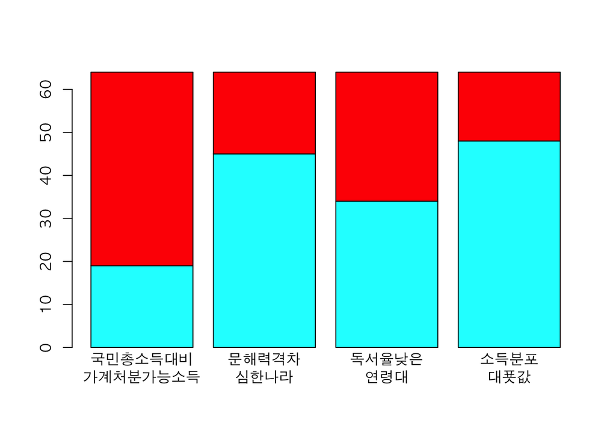

```r
barplot(marks.tbl.2, col=c("cyan", "red"), names.arg = v.names)
```

- 메인 타이틀과 x축, y축의 제목 추가

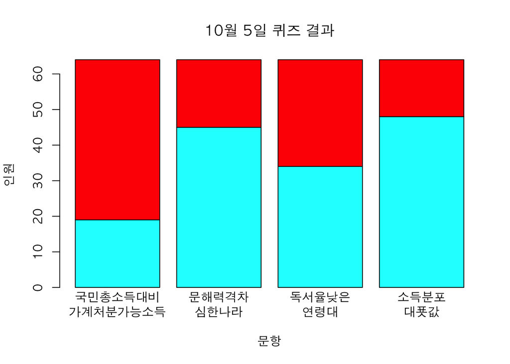

```r
barplot(marks.tbl.2, col=c("cyan", "red"), names.arg = v.names)
title(main="10월 5일 퀴즈 결과", xlab="문항", ylab="인원")
```

- 범례 추가
  - 좌표는 시행착오를 거쳐서 찾아냄.

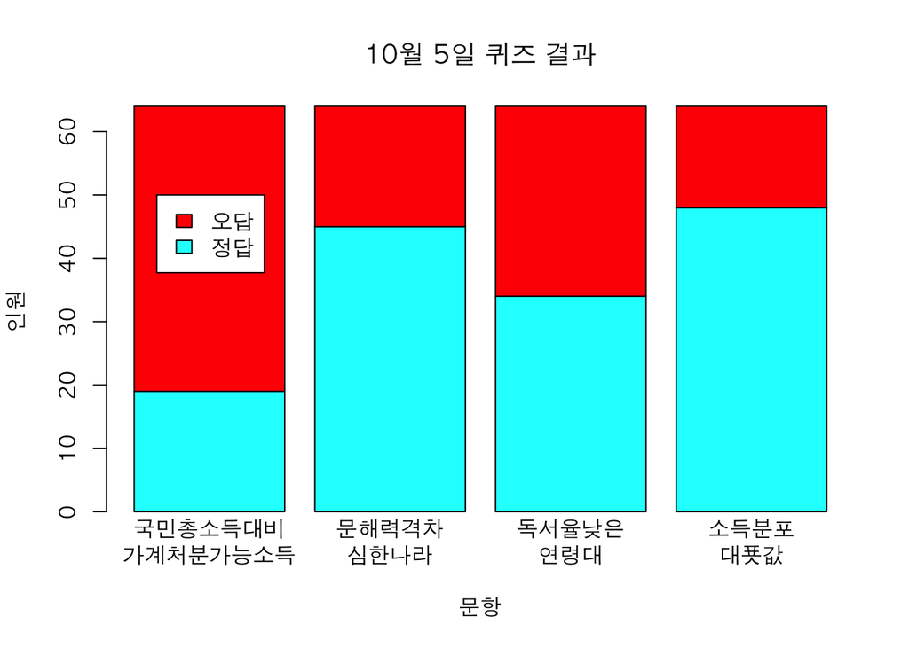

```r
barplot(marks.tbl.2, col=c("cyan", "red"), names.arg = v.names)
title(main="10월 5일 퀴즈 결과", xlab="문항", ylab="인원")
legend(x=0.35, y=50, legend=c("오답", "정답"), fill=c("red", "cyan"))
```

- 각 막대에 정답률(%) 표시
  - 좌표는 역시 시행착오를 거쳐 찾아냄.

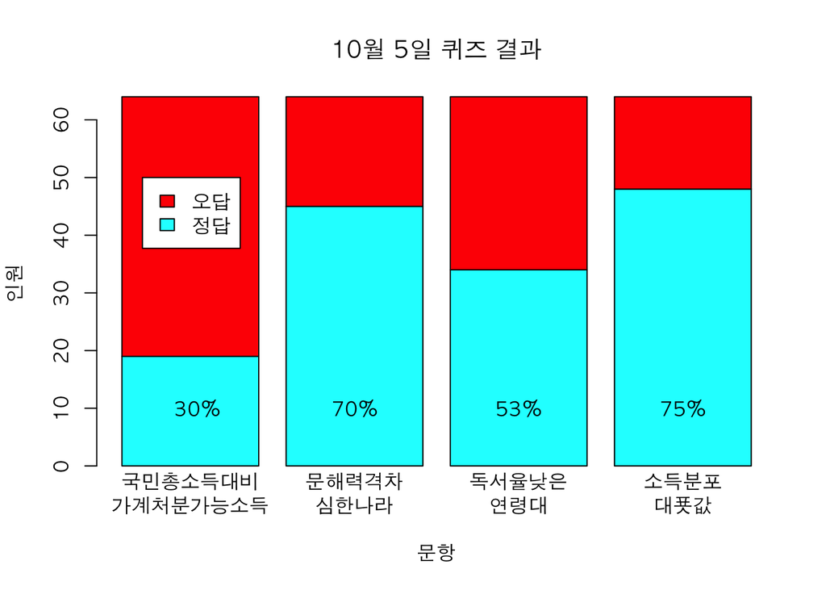

```r
barplot(marks.tbl.2, col=c("cyan", "red"), names.arg = v.names)
title(main="10월 5일 퀴즈 결과", xlab="문항", ylab="인원")
legend(x=0.35, y=50, legend=c("오답", "정답"), fill=c("red", "cyan"))
text(x=c(0.75, 1.9, 3.1, 4.3), y=rep(10, 4), labels=paste(correct.ans.rate, "%", sep=""))
```

## `ggplot()` 접근

### Two types of long format

- ggplot으로 그리려면 long format 필요
  - `marks`의 자료구조가 매트릭스이므로 `reshape2::melt`의 array(matrix, table) 유형에 적용.
  - matrix의 행이름과 열이름을 붙이는 방법에 대하여 유의하고,
  - 행이름과 열이름이 어떻게 등장하는지 살필 것.
  - `"ID"`와 `"Items"`를 `dimnames()`로 설정하지 않으면 `Var1`과 `Var2`로 나타나게 됨.
  - `value.name`을 설정하지 않으면 `value`라는 변수명을 갖게 됨. 확인해 볼 것.

```r
library(reshape2)
str(marks)
```

```
##  chr [1:70, 1:4] "W" "W" "W" "W" "W" "R" "W" NA "W" ...
##  - attr(*, "dimnames")=List of 2
##   ..$ : NULL
##   ..$ : chr [1:4] "A1" "A2" "A3" "A4"
```

```r
dimnames(marks) <- list("ID" = quiz1005$id, "Items" = dimnames(marks)[[2]])
# dimnames(marks) <- list("ID" = dimnames(marks)[[1]], "Items" = dimnames(marks)[[2]])
str(marks)
```

```
##  chr [1:70, 1:4] "W" "W" "W" "W" "W" "R" "W" NA "W" ...
##  - attr(*, "dimnames")=List of 2
##   ..$ ID   : chr [1:70] "20128005" "20113201" "20152802" "20152652" ...
##   ..$ Items: chr [1:4] "A1" "A2" "A3" "A4"
```

```r
(marks.long <- melt(marks, value.name="Marks"))
```

```
##           ID Items Marks
## 1   20128005    A1     W
## 2   20113201    A1     W
## 3   20152802    A1     W
## 4   20152652    A1     W
## 5   20142510    A1     W
## 6   20121103    A1     R
## 7   20154307    A1     W
## 8   20093404    A1  <NA>
## 9   20151401    A1     W
## 10  20112405    A1     R
## 11  20113207    A1     R
## 12  20112822    A1  <NA>
## 13  20095315    A1     W
## 14  20121109    A1     R
```

[output cut: 266 more lines]

```r
str(marks.long)
```

```
## 'data.frame':    280 obs. of  3 variables:
##  $ ID   : int  20128005 20113201 20152802 20152652 20142510 20121103 20154307 20093404 20151401 20112405 ...
##  $ Items: Factor w/ 4 levels "A1","A2","A3",..: 1 1 1 1 1 1 1 1 1 1 ...
##  $ Marks: chr  "W" "W" "W" "W" ...
```

- `ggplot` 기본 골격

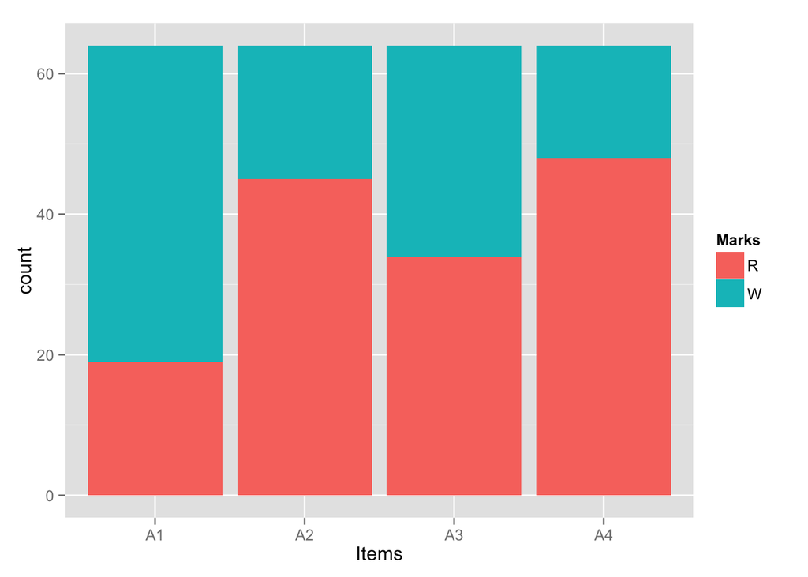

```r
(ml.1 <- ggplot(na.omit(marks.long), aes(x=Items, fill=Marks)) + geom_bar(stat="bin"))
```

- 흑백 배경 전환

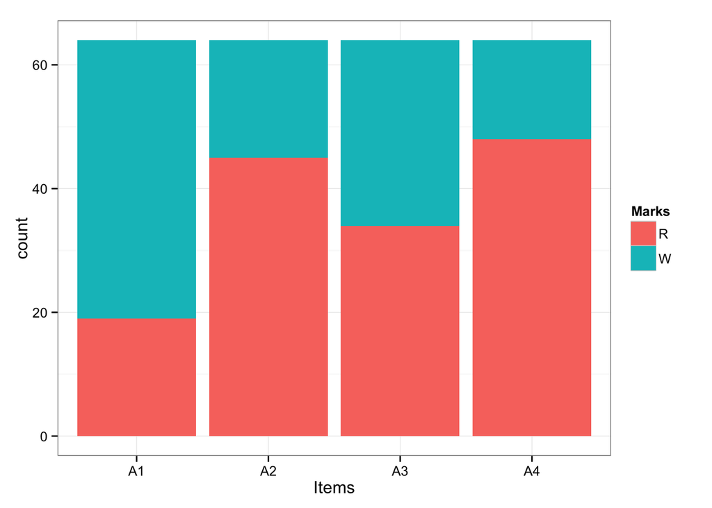

```r
(ml.2 <- ml.1 + theme_bw())
```

- 한글로 제목과 축이름 붙이기

```r
source("theme_kr_HCR.R")
ls()
```

```
##  [1] "correct.ans.rate"  "marks"             "marks.long"
##  [4] "marks.tbl"         "marks.tbl.2"       "marks.tbl.long"
##  [7] "ml.1"              "ml.2"              "ml.3"
## [10] "ml.4"              "ml.5"              "ml.6"
## [13] "ml.7"              "ml.8"              "mtl.1"
## [16] "mtl.2"             "mtl.3"             "mtl.4"
## [19] "mtl.5"             "mtl.6"             "mtl.7"
## [22] "mtl.8"             "q.ans"             "q.ans.hard.times"
## [25] "q.ans.mean.median" "q.ans.pdi"         "q.ans.reading"
## [28] "q.ans.tbl"         "q.key"             "q.key.l"
## [31] "quiz1005"          "quiz1007"          "theme.HCR.kr"
## [34] "v.names"
```

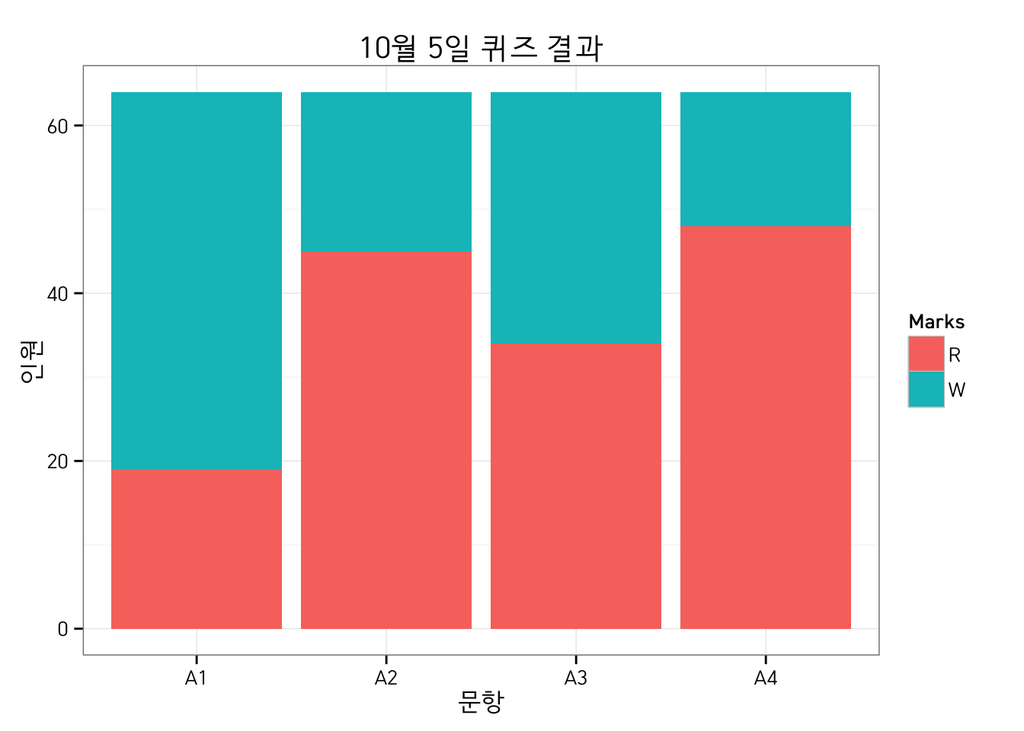

```r
(ml.3 <- ml.2 + theme.HCR.kr + xlab("문항") + ylab("인원") + ggtitle("10월 5일 퀴즈 결과"))
```

- 한글로 막대에 문항별 이름 붙이기

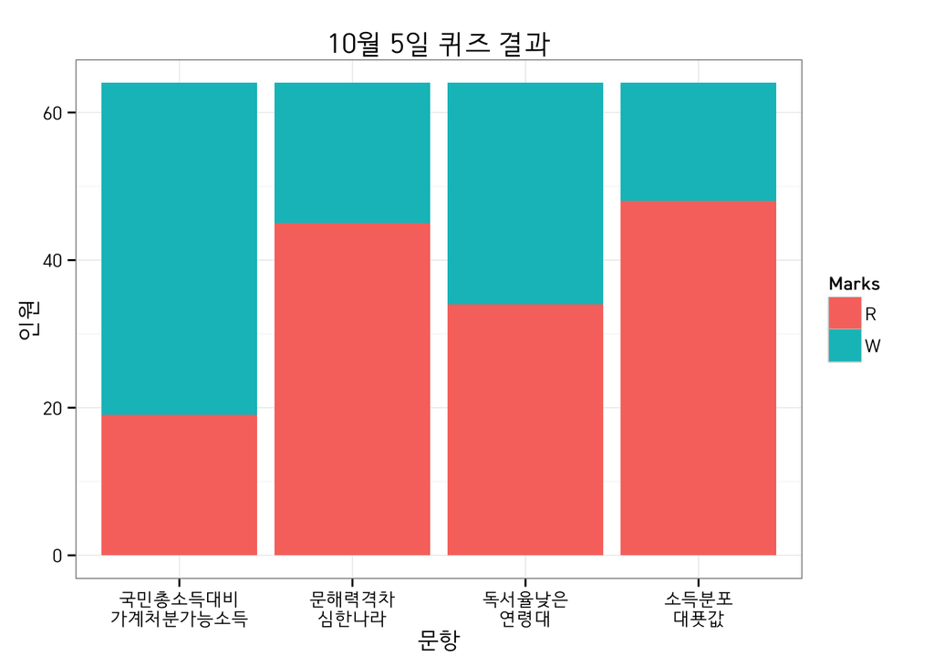

```r
(ml.4 <- ml.3 + scale_x_discrete(labels=v.names))
```

- `legend`에 한글이름 붙이기

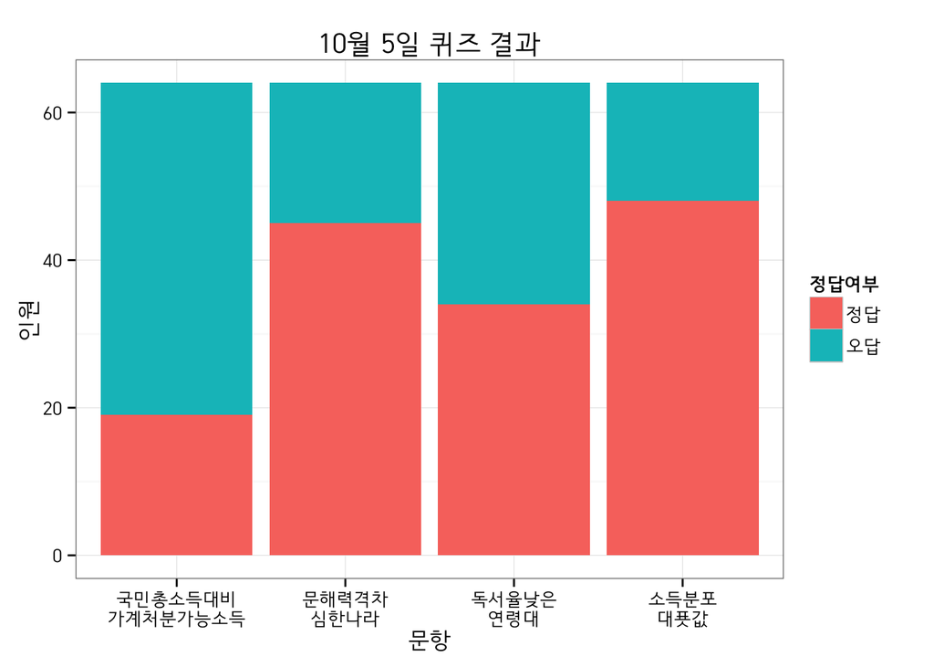

```r
(ml.5 <- ml.4 + labs(fill="정답여부") + scale_fill_discrete(labels=c("정답", "오답")))
```

- 색이 맘에 안 들면,

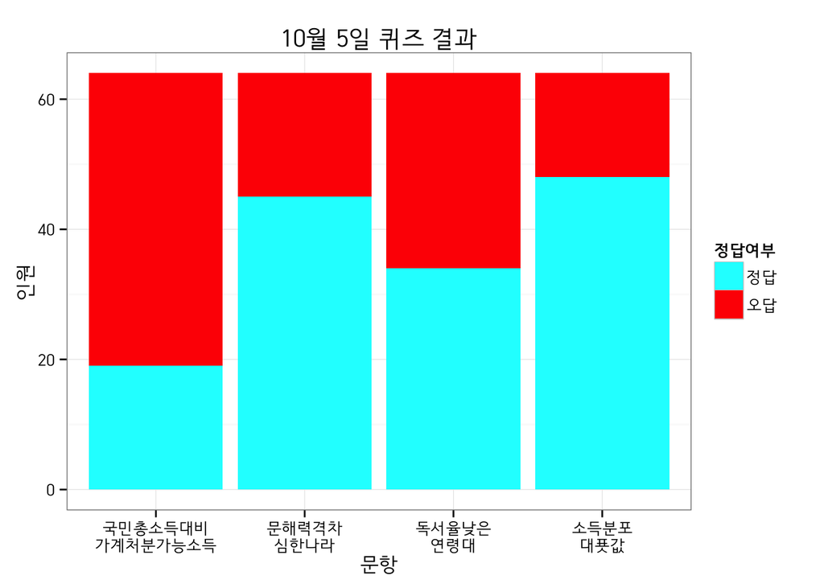

```r
(ml.6 <- ml.4 + scale_fill_manual(values=c("cyan", "red"), labels=c("정답", "오답")) + labs(fill="정답여부"))
```

- 범례 항목의 등장 순서를 바꾸려면,

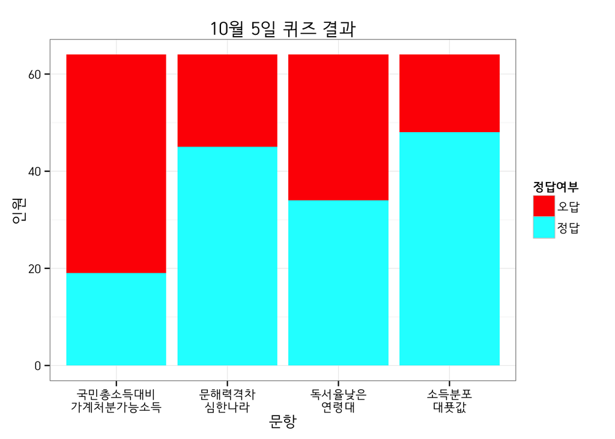

```r
(ml.7 <- ml.4 + scale_fill_manual(limits=c("W", "R"), values=c("red", "cyan"), labels=c("오답", "정답")) + labs(fill="정답여부"))
```

- 정답률을 각 막대에 새기기

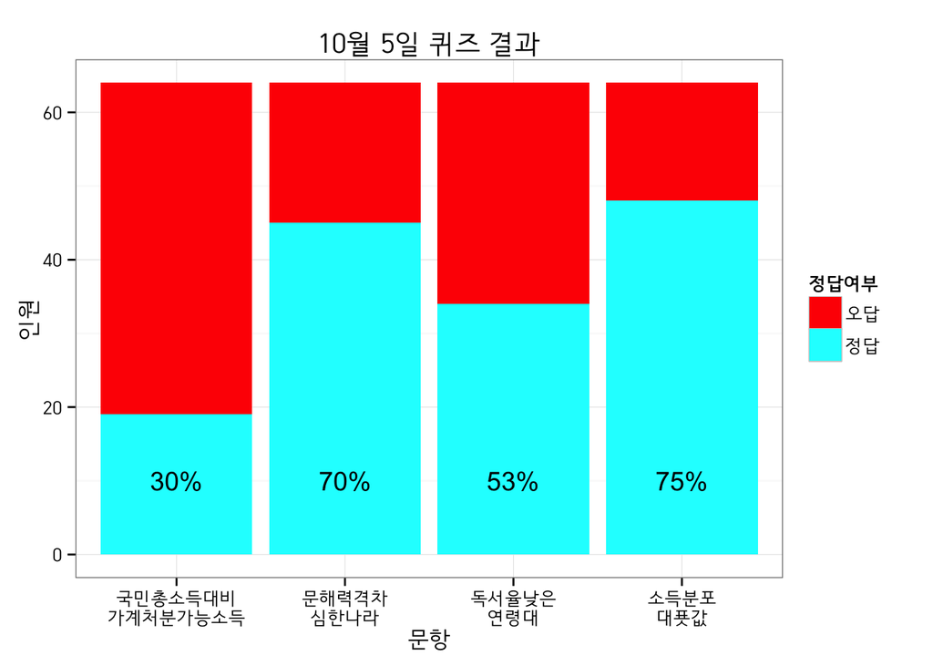

```r
(ml.8 <- ml.7 + annotate("text", x=1:4, y=rep(10, 4), label=paste(correct.ans.rate, "%", sep="")))
```

### `marks.tbl`로 그리려면,

- `marks.tbl`을 logn format으로 전환

```r
str(marks.tbl)
```

```
##  int [1:3, 1:4] 19 45 6 45 19 6 34 30 6 48 ...
##  - attr(*, "dimnames")=List of 2
##   ..$ : chr [1:3] "R" "W" NA
##   ..$ : chr [1:4] "A1" "A2" "A3" "A4"
```

```r
dimnames(marks.tbl) <- list("Marks"= dimnames(marks.tbl)[[1]], "Items" = dimnames(marks.tbl)[[2]])
str(marks.tbl)
```

```
##  int [1:3, 1:4] 19 45 6 45 19 6 34 30 6 48 ...
##  - attr(*, "dimnames")=List of 2
##   ..$ Marks: chr [1:3] "R" "W" NA
##   ..$ Items: chr [1:4] "A1" "A2" "A3" "A4"
```

```r
(marks.tbl.long <- melt(marks.tbl, value.name="Counts"))
```

```
##    Marks Items Counts
## 1      R    A1     19
## 2      W    A1     45
## 3   <NA>    A1      6
## 4      R    A2     45
## 5      W    A2     19
## 6   <NA>    A2      6
## 7      R    A3     34
## 8      W    A3     30
## 9   <NA>    A3      6
## 10     R    A4     48
## 11     W    A4     16
## 12  <NA>    A4      6
```

```r
str(marks.tbl.long)
```

```
## 'data.frame':    12 obs. of  3 variables:
##  $ Marks : Factor w/ 2 levels "R","W": 1 2 NA 1 2 NA 1 2 NA 1 ...
##  $ Items : Factor w/ 4 levels "A1","A2","A3",..: 1 1 1 2 2 2 3 3 3 4 ...
##  $ Counts: int  19 45 6 45 19 6 34 30 6 48 ...
```

- `ggplot` 골격
  - `aes()`에 `y = Counts` 등장.

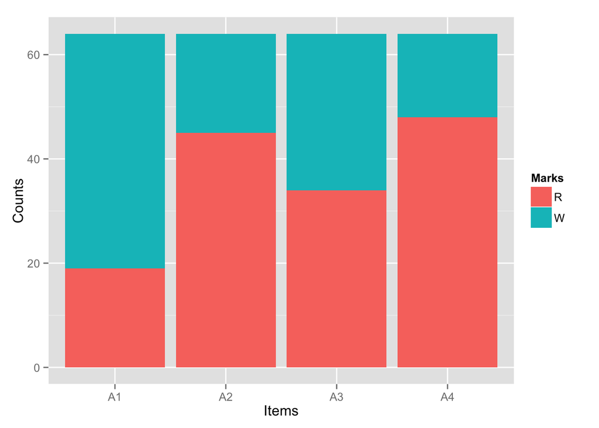

```r
(mtl.1 <- ggplot(na.omit(marks.tbl.long), aes(x = Items, y = Counts, fill = Marks)) +
  geom_bar(stat="identity"))
```

- 흑백 배경 전환

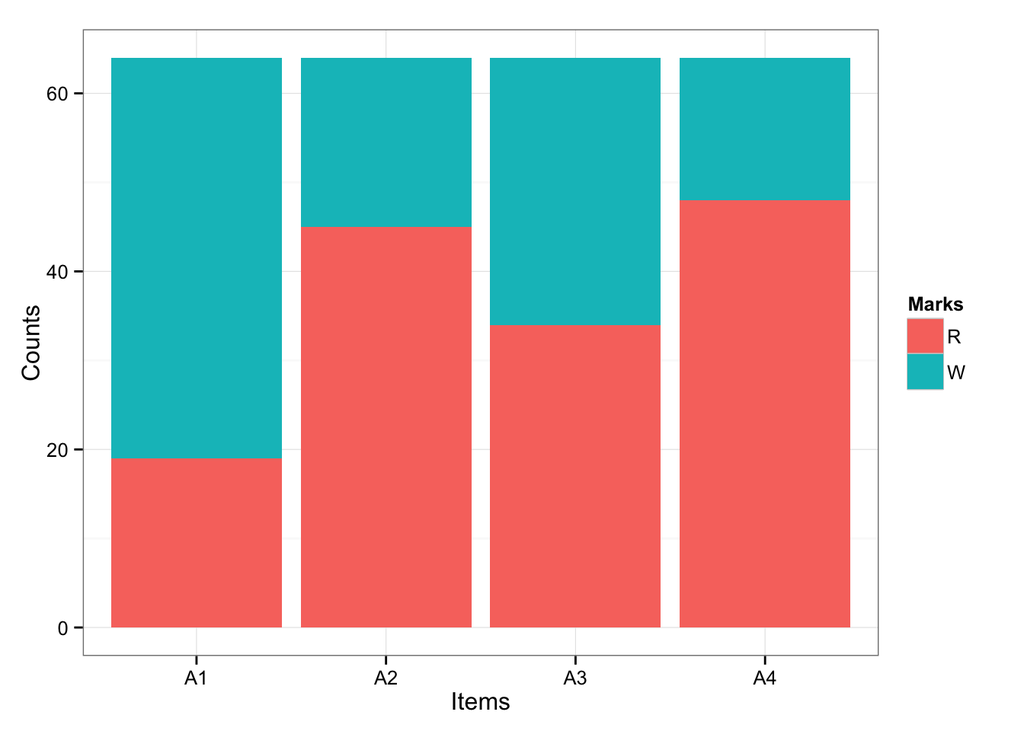

```r
(mtl.2 <- mtl.1 + theme_bw())
```

- 한글로 제목과 축이름 붙이기

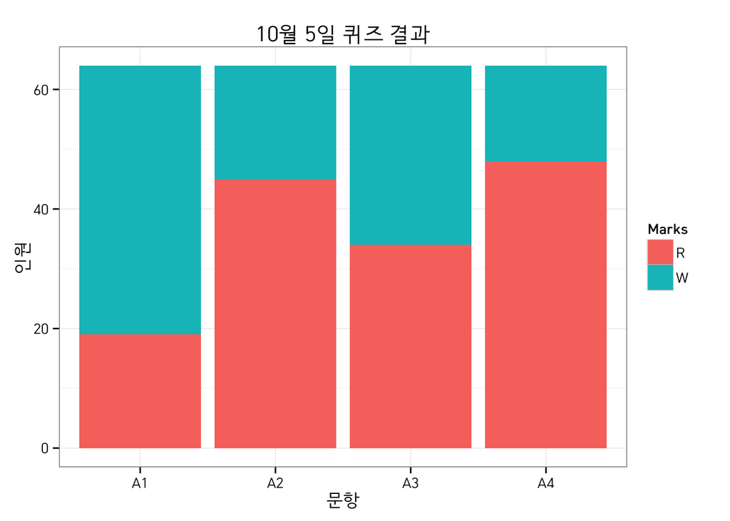

```r
(mtl.3 <- mtl.2 + theme.HCR.kr + xlab("문항") + ylab("인원") + ggtitle("10월 5일 퀴즈 결과"))
```

- 한글로 막대에 문항별 이름 붙이기

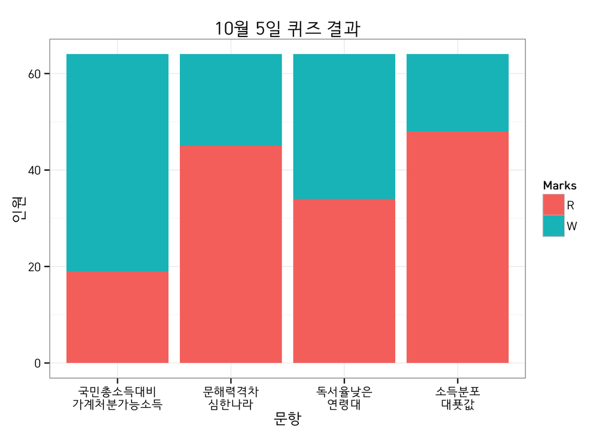

```r
(mtl.4 <- mtl.3 + scale_x_discrete(labels=v.names))
```

- `legend`에 한글이름 붙이기

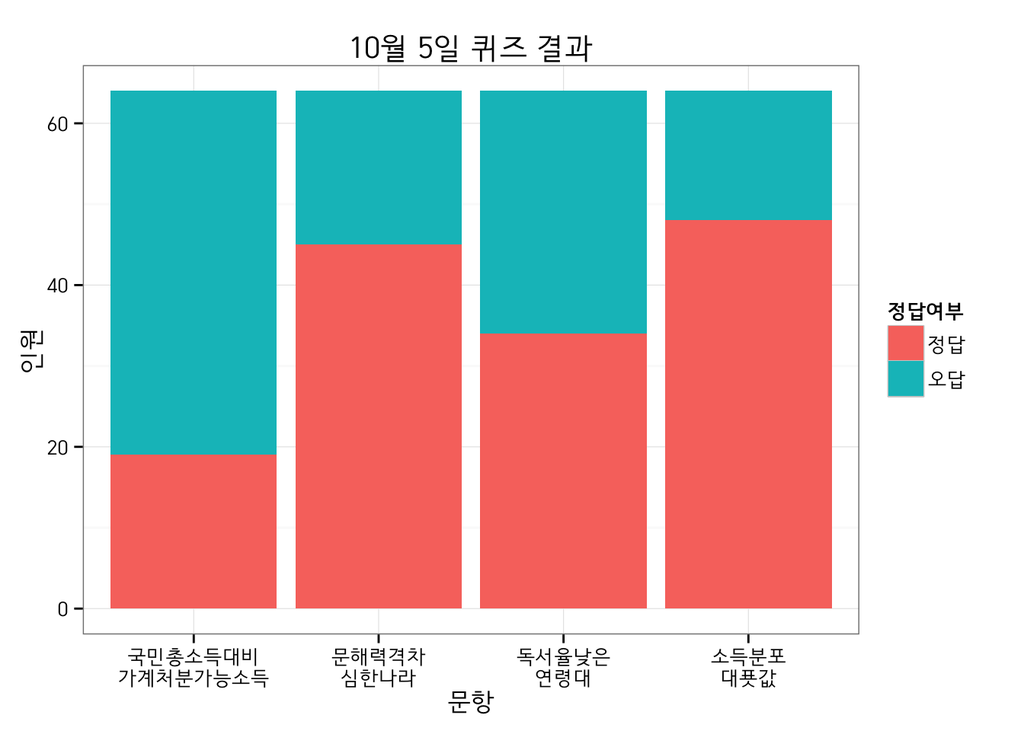

```r
(mtl.5 <- mtl.4 + labs(fill="정답여부") + scale_fill_discrete(labels=c("정답", "오답")))
```

- 색이 맘에 안 들면,

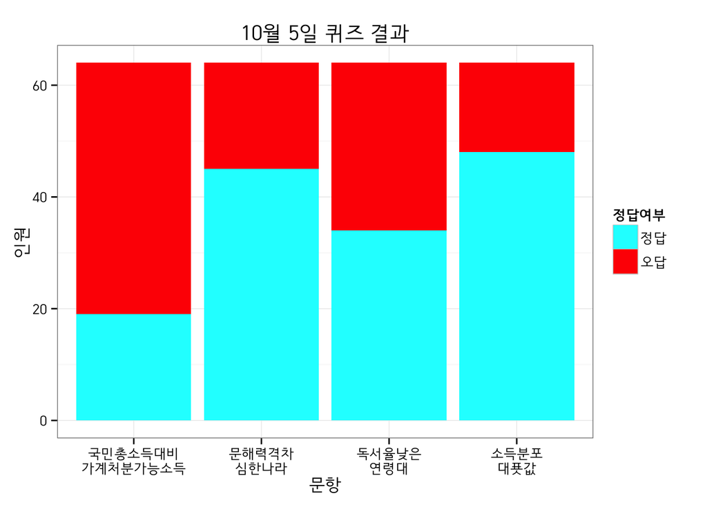

```r
(mtl.6 <- mtl.4 + scale_fill_manual(values=c("cyan", "red"), labels=c("정답", "오답")) + labs(fill="정답여부"))
```

- 범례 항목의 등장 순서를 바꾸려면,

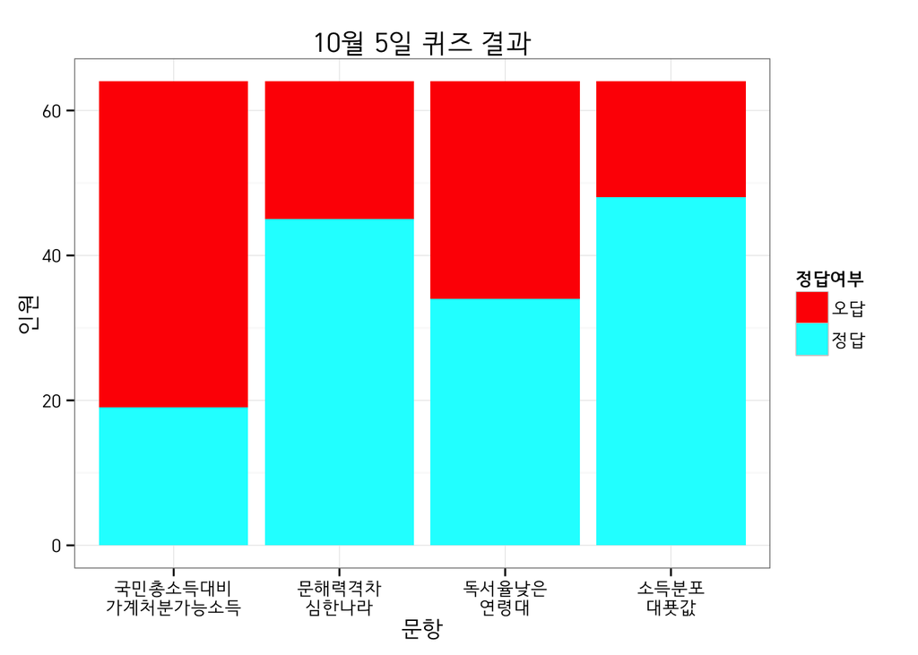

```r
(mtl.7 <- mtl.4 + scale_fill_manual(limits=c("W", "R"), values=c("red", "cyan"), labels=c("오답", "정답")) + labs(fill="정답여부"))
```

- 정답률을 각 막대에 새기기

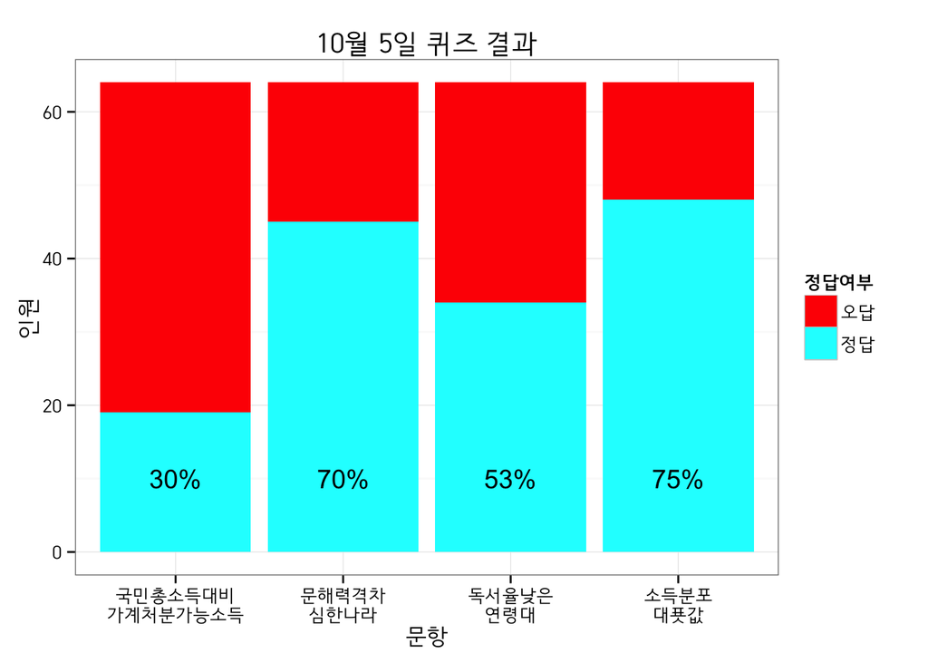

```r
(mtl.8 <- mtl.7 + annotate("text", x=1:4, y=rep(10, 4), label=paste(correct.ans.rate, "%", sep="")))
```

## 자료 갈무리

```r
save.image("quiz_1005.rda")
```